# Optimal Treatment Analysis

## Outcome Variable

**Outcome Variable:** whz

## Predictor Variables

**Intervention Variable:** perdiar6

**Adjustment Set:**

- arm
- sex
- W_mage
- meducyrs
- W_mhtcm
- W_mwtkg
- W_mbmi
- W_birthwt
- W_birthlen
- W_nrooms
- month
- brthmon
- impfloor
- impsan
- safeh20
- delta_W_mage
- delta_meducyrs
- delta_W_mhtcm
- delta_W_mwtkg
- delta_W_mbmi
- delta_W_birthwt
- delta_W_birthlen
- delta_W_nrooms
- delta_month
- delta_brthmon
- delta_impfloor
- delta_impsan
- delta_safeh20

## Stratifying Variables

The analysis was stratified on these variable(s):

- agecat
- studyid
- country

## Data Summary

| agecat | studyid | country | perdiar6 | n_cell | n |
| --- | --- | --- | --- | --- | --- |
| Birth | ki0047075b-MAL-ED | BANGLADESH | 0% | 79 | 241 |
| Birth | ki0047075b-MAL-ED | BANGLADESH | (0%, 5%] | 92 | 241 |
| Birth | ki0047075b-MAL-ED | BANGLADESH | >5% | 70 | 241 |
| Birth | ki0047075b-MAL-ED | BRAZIL | 0% | 169 | 183 |
| Birth | ki0047075b-MAL-ED | BRAZIL | (0%, 5%] | 12 | 183 |
| Birth | ki0047075b-MAL-ED | BRAZIL | >5% | 2 | 183 |
| Birth | ki0047075b-MAL-ED | INDIA | 0% | 46 | 203 |
| Birth | ki0047075b-MAL-ED | INDIA | (0%, 5%] | 107 | 203 |
| Birth | ki0047075b-MAL-ED | INDIA | >5% | 50 | 203 |
| Birth | ki0047075b-MAL-ED | NEPAL | 0% | 56 | 168 |
| Birth | ki0047075b-MAL-ED | NEPAL | (0%, 5%] | 57 | 168 |
| Birth | ki0047075b-MAL-ED | NEPAL | >5% | 55 | 168 |
| Birth | ki0047075b-MAL-ED | PERU | 0% | 82 | 279 |
| Birth | ki0047075b-MAL-ED | PERU | (0%, 5%] | 84 | 279 |
| Birth | ki0047075b-MAL-ED | PERU | >5% | 113 | 279 |
| Birth | ki0047075b-MAL-ED | SOUTH AFRICA | 0% | 192 | 250 |
| Birth | ki0047075b-MAL-ED | SOUTH AFRICA | (0%, 5%] | 49 | 250 |
| Birth | ki0047075b-MAL-ED | SOUTH AFRICA | >5% | 9 | 250 |
| Birth | ki0047075b-MAL-ED | TANZANIA, UNITED REPUBLIC OF | 0% | 59 | 118 |
| Birth | ki0047075b-MAL-ED | TANZANIA, UNITED REPUBLIC OF | (0%, 5%] | 40 | 118 |
| Birth | ki0047075b-MAL-ED | TANZANIA, UNITED REPUBLIC OF | >5% | 19 | 118 |
| Birth | ki1000109-ResPak | PAKISTAN | 0% | 0 | 5 |
| Birth | ki1000109-ResPak | PAKISTAN | (0%, 5%] | 2 | 5 |
| Birth | ki1000109-ResPak | PAKISTAN | >5% | 3 | 5 |
| Birth | ki1017093-NIH-Birth | BANGLADESH | 0% | 4 | 26 |
| Birth | ki1017093-NIH-Birth | BANGLADESH | (0%, 5%] | 3 | 26 |
| Birth | ki1017093-NIH-Birth | BANGLADESH | >5% | 19 | 26 |
| Birth | ki1017093c-NIH-Crypto | BANGLADESH | 0% | 6 | 23 |
| Birth | ki1017093c-NIH-Crypto | BANGLADESH | (0%, 5%] | 7 | 23 |
| Birth | ki1017093c-NIH-Crypto | BANGLADESH | >5% | 10 | 23 |

[output cut: 102 more lines]

The following strata were considered:

- agecat: 24 months, studyid: ki0047075b-MAL-ED, country: BANGLADESH
- agecat: 24 months, studyid: ki0047075b-MAL-ED, country: BRAZIL
- agecat: 24 months, studyid: ki0047075b-MAL-ED, country: INDIA
- agecat: 24 months, studyid: ki0047075b-MAL-ED, country: NEPAL
- agecat: 24 months, studyid: ki0047075b-MAL-ED, country: PERU
- agecat: 24 months, studyid: ki0047075b-MAL-ED, country: SOUTH AFRICA
- agecat: 24 months, studyid: ki0047075b-MAL-ED, country: TANZANIA, UNITED REPUBLIC OF
- agecat: 24 months, studyid: ki1017093-NIH-Birth, country: BANGLADESH
- agecat: 24 months, studyid: ki1017093b-PROVIDE, country: BANGLADESH
- agecat: 24 months, studyid: ki1017093c-NIH-Crypto, country: BANGLADESH
- agecat: 24 months, studyid: ki1114097-CMIN, country: BANGLADESH
- agecat: 24 months, studyid: ki1114097-CMIN, country: GUINEA-BISSAU
- agecat: 24 months, studyid: ki1114097-CMIN, country: PERU
- agecat: 24 months, studyid: ki1114097-CONTENT, country: PERU
- agecat: 6 months, studyid: ki0047075b-MAL-ED, country: BANGLADESH
- agecat: 6 months, studyid: ki0047075b-MAL-ED, country: BRAZIL
- agecat: 6 months, studyid: ki0047075b-MAL-ED, country: INDIA
- agecat: 6 months, studyid: ki0047075b-MAL-ED, country: NEPAL
- agecat: 6 months, studyid: ki0047075b-MAL-ED, country: PERU
- agecat: 6 months, studyid: ki0047075b-MAL-ED, country: SOUTH AFRICA
- agecat: 6 months, studyid: ki0047075b-MAL-ED, country: TANZANIA, UNITED REPUBLIC OF
- agecat: 6 months, studyid: ki1000109-ResPak, country: PAKISTAN
- agecat: 6 months, studyid: ki1017093-NIH-Birth, country: BANGLADESH
- agecat: 6 months, studyid: ki1017093b-PROVIDE, country: BANGLADESH
- agecat: 6 months, studyid: ki1017093c-NIH-Crypto, country: BANGLADESH
- agecat: 6 months, studyid: ki1114097-CMIN, country: BANGLADESH
- agecat: 6 months, studyid: ki1114097-CMIN, country: BRAZIL
- agecat: 6 months, studyid: ki1114097-CMIN, country: GUINEA-BISSAU
- agecat: 6 months, studyid: ki1114097-CMIN, country: PERU
- agecat: 6 months, studyid: ki1114097-CONTENT, country: PERU
- agecat: Birth, studyid: ki0047075b-MAL-ED, country: BANGLADESH
- agecat: Birth, studyid: ki0047075b-MAL-ED, country: BRAZIL
- agecat: Birth, studyid: ki0047075b-MAL-ED, country: INDIA
- agecat: Birth, studyid: ki0047075b-MAL-ED, country: NEPAL
- agecat: Birth, studyid: ki0047075b-MAL-ED, country: PERU
- agecat: Birth, studyid: ki0047075b-MAL-ED, country: SOUTH AFRICA
- agecat: Birth, studyid: ki0047075b-MAL-ED, country: TANZANIA, UNITED REPUBLIC OF
- agecat: Birth, studyid: ki1000109-ResPak, country: PAKISTAN
- agecat: Birth, studyid: ki1017093-NIH-Birth, country: BANGLADESH
- agecat: Birth, studyid: ki1017093c-NIH-Crypto, country: BANGLADESH
- agecat: Birth, studyid: ki1114097-CMIN, country: BANGLADESH
- agecat: Birth, studyid: ki1114097-CMIN, country: BRAZIL
- agecat: Birth, studyid: ki1114097-CMIN, country: PERU
- agecat: Birth, studyid: ki1114097-CONTENT, country: PERU

### Dropped Strata

Some strata were dropped due to rare outcomes:

- agecat: Birth, studyid: ki0047075b-MAL-ED, country: BRAZIL
- agecat: Birth, studyid: ki1000109-ResPak, country: PAKISTAN
- agecat: Birth, studyid: ki1017093-NIH-Birth, country: BANGLADESH
- agecat: Birth, studyid: ki1114097-CMIN, country: BANGLADESH
- agecat: Birth, studyid: ki1114097-CMIN, country: PERU
- agecat: Birth, studyid: ki1114097-CONTENT, country: PERU
- agecat: 6 months, studyid: ki0047075b-MAL-ED, country: BRAZIL
- agecat: 24 months, studyid: ki0047075b-MAL-ED, country: BRAZIL

## Methods Detail

We’re interested in the causal parameters $E[Y_a]$ for all values of $a \in \mathcal{A}$. These parameters represent the mean outcome if, possibly contrary to fact, we intervened to set all units to have $A=a$. Under the randomization and positivity assumptions, these are identified by the statistical parameters $\psi_a=E_W[E_{Y|A,W}(Y|A=a,W)]$. In addition, we’re interested in the mean of $Y$, $E[Y]$ under no intervention (the observed mean). We will estimate these parameters by using SuperLearner to fit the relevant likelihood factors – $E_{Y|A,W}(Y|A=a,W)$ and $p(A=a|W)$, and then updating our likelihood fit using a joint TMLE.

For unadjusted analyses ($W=\{\}$), initial likelihoods were estimated using Lrnr_glm to estimate the simple $E(Y|A)$ and Lrnr_mean to estimate $p(A)$. For adjusted analyses, a small library containing Lrnr_glmnet, Lrnr_xgboost, and Lrnr_mean was used.

# Results Detail

## Results Plots

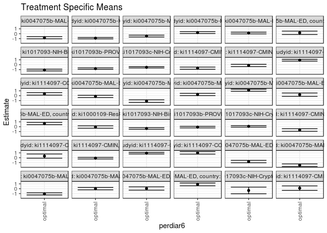

## Results Table

### Parameter: TSM

| agecat | studyid | country | intervention_level | baseline_level | estimate | ci_lower | ci_upper |
| --- | --- | --- | --- | --- | --- | --- | --- |
| Birth | ki0047075b-MAL-ED | BANGLADESH | optimal | observed | -0.7843109 | -1.0324957 | -0.5361262 |
| Birth | ki0047075b-MAL-ED | INDIA | optimal | observed | -1.5231031 | -1.7894538 | -1.2567524 |
| Birth | ki0047075b-MAL-ED | NEPAL | optimal | observed | -1.0467344 | -1.2674860 | -0.8259828 |
| Birth | ki0047075b-MAL-ED | PERU | optimal | observed | 0.0149991 | -0.2285462 | 0.2585445 |
| Birth | ki0047075b-MAL-ED | SOUTH AFRICA | optimal | observed | 0.0501935 | -0.2801485 | 0.3805354 |
| Birth | ki0047075b-MAL-ED | TANZANIA, UNITED REPUBLIC OF | optimal | observed | 0.8856450 | 0.6032147 | 1.1680752 |
| Birth | ki1017093c-NIH-Crypto | BANGLADESH | optimal | observed | -0.3567889 | -1.0401684 | 0.3265906 |
| Birth | ki1114097-CMIN | BRAZIL | optimal | observed | 0.1195651 | -0.3387120 | 0.5778421 |
| 6 months | ki0047075b-MAL-ED | BANGLADESH | optimal | observed | -0.1348238 | -0.3626360 | 0.0929885 |
| 6 months | ki0047075b-MAL-ED | INDIA | optimal | observed | -1.0904347 | -1.3573057 | -0.8235638 |
| 6 months | ki0047075b-MAL-ED | NEPAL | optimal | observed | 0.2581426 | 0.0271646 | 0.4891207 |
| 6 months | ki0047075b-MAL-ED | PERU | optimal | observed | 1.1294746 | 0.9101335 | 1.3488157 |
| 6 months | ki0047075b-MAL-ED | SOUTH AFRICA | optimal | observed | 0.2173056 | -0.1241815 | 0.5587927 |
| 6 months | ki0047075b-MAL-ED | TANZANIA, UNITED REPUBLIC OF | optimal | observed | 0.6514870 | 0.4182594 | 0.8847146 |
| 6 months | ki1000109-ResPak | PAKISTAN | optimal | observed | -0.0572532 | -0.3057278 | 0.1912214 |
| 6 months | ki1017093-NIH-Birth | BANGLADESH | optimal | observed | -0.3546452 | -0.5238289 | -0.1854614 |
| 6 months | ki1017093b-PROVIDE | BANGLADESH | optimal | observed | -0.0763257 | -0.2387844 | 0.0861329 |
| 6 months | ki1017093c-NIH-Crypto | BANGLADESH | optimal | observed | 0.0793573 | -0.0794775 | 0.2381921 |
| 6 months | ki1114097-CMIN | BANGLADESH | optimal | observed | -0.6629115 | -0.9236827 | -0.4021403 |
| 6 months | ki1114097-CMIN | BRAZIL | optimal | observed | 0.3358659 | -0.0862698 | 0.7580016 |
| 6 months | ki1114097-CMIN | GUINEA-BISSAU | optimal | observed | -0.0882574 | -0.2546509 | 0.0781362 |
| 6 months | ki1114097-CMIN | PERU | optimal | observed | 0.9289805 | 0.7682020 | 1.0897591 |
| 6 months | ki1114097-CONTENT | PERU | optimal | observed | 0.9946848 | 0.7391712 | 1.2501985 |
| 24 months | ki0047075b-MAL-ED | BANGLADESH | optimal | observed | -0.8145989 | -1.0356026 | -0.5935953 |
| 24 months | ki0047075b-MAL-ED | INDIA | optimal | observed | -0.9086672 | -1.0540981 | -0.7632363 |
| 24 months | ki0047075b-MAL-ED | NEPAL | optimal | observed | -0.4807587 | -0.6758316 | -0.2856857 |
| 24 months | ki0047075b-MAL-ED | PERU | optimal | observed | 0.2315356 | 0.0413088 | 0.4217624 |
| 24 months | ki0047075b-MAL-ED | SOUTH AFRICA | optimal | observed | 0.1414849 | -0.0305868 | 0.3135566 |
| 24 months | ki0047075b-MAL-ED | TANZANIA, UNITED REPUBLIC OF | optimal | observed | 0.1891772 | -0.1561679 | 0.5345222 |
| 24 months | ki1017093-NIH-Birth | BANGLADESH | optimal | observed | -1.0826342 | -1.2650901 | -0.9001783 |
| 24 months | ki1017093b-PROVIDE | BANGLADESH | optimal | observed | -0.7922684 | -0.9451142 | -0.6394226 |
| 24 months | ki1017093c-NIH-Crypto | BANGLADESH | optimal | observed | -0.5292921 | -0.6652999 | -0.3932842 |
| 24 months | ki1114097-CMIN | BANGLADESH | optimal | observed | -0.6971491 | -0.9133287 | -0.4809695 |
| 24 months | ki1114097-CMIN | GUINEA-BISSAU | optimal | observed | -0.1470217 | -0.3834052 | 0.0893617 |
| 24 months | ki1114097-CMIN | PERU | optimal | observed | 0.9283018 | 0.7500971 | 1.1065064 |
| 24 months | ki1114097-CONTENT | PERU | optimal | observed | 0.3849334 | 0.1282668 | 0.6416000 |

### Parameter: E(Y)

| agecat | studyid | country | intervention_level | baseline_level | estimate | ci_lower | ci_upper |
| --- | --- | --- | --- | --- | --- | --- | --- |
| Birth | ki0047075b-MAL-ED | BANGLADESH | observed | observed | -0.9630705 | -1.0989132 | -0.8272278 |
| Birth | ki0047075b-MAL-ED | INDIA | observed | observed | -1.0691133 | -1.2078629 | -0.9303637 |
| Birth | ki0047075b-MAL-ED | NEPAL | observed | observed | -0.9044643 | -1.0439568 | -0.7649718 |
| Birth | ki0047075b-MAL-ED | PERU | observed | observed | -0.0735842 | -0.1836203 | 0.0364518 |
| Birth | ki0047075b-MAL-ED | SOUTH AFRICA | observed | observed | -0.0415200 | -0.1860797 | 0.1030397 |
| Birth | ki0047075b-MAL-ED | TANZANIA, UNITED REPUBLIC OF | observed | observed | 0.7932203 | 0.5962220 | 0.9902187 |
| Birth | ki1017093c-NIH-Crypto | BANGLADESH | observed | observed | -0.7508696 | -1.2358912 | -0.2658480 |
| Birth | ki1114097-CMIN | BRAZIL | observed | observed | -0.1332432 | -0.3441055 | 0.0776190 |
| 6 months | ki0047075b-MAL-ED | BANGLADESH | observed | observed | -0.1397960 | -0.2688682 | -0.0107238 |
| 6 months | ki0047075b-MAL-ED | INDIA | observed | observed | -0.7033969 | -0.8285284 | -0.5782654 |
| 6 months | ki0047075b-MAL-ED | NEPAL | observed | observed | 0.1110452 | -0.0202712 | 0.2423616 |
| 6 months | ki0047075b-MAL-ED | PERU | observed | observed | 1.0543956 | 0.9326967 | 1.1760945 |
| 6 months | ki0047075b-MAL-ED | SOUTH AFRICA | observed | observed | 0.5420735 | 0.3899459 | 0.6942011 |
| 6 months | ki0047075b-MAL-ED | TANZANIA, UNITED REPUBLIC OF | observed | observed | 0.5170513 | 0.3872178 | 0.6468847 |
| 6 months | ki1000109-ResPak | PAKISTAN | observed | observed | -0.1683617 | -0.3528233 | 0.0160999 |
| 6 months | ki1017093-NIH-Birth | BANGLADESH | observed | observed | -0.4389101 | -0.5279432 | -0.3498771 |
| 6 months | ki1017093b-PROVIDE | BANGLADESH | observed | observed | -0.2083706 | -0.2927992 | -0.1239419 |
| 6 months | ki1017093c-NIH-Crypto | BANGLADESH | observed | observed | 0.0297622 | -0.0491685 | 0.1086930 |
| 6 months | ki1114097-CMIN | BANGLADESH | observed | observed | -0.5780453 | -0.7226627 | -0.4334279 |
| 6 months | ki1114097-CMIN | BRAZIL | observed | observed | 0.5889815 | 0.3767666 | 0.8011963 |
| 6 months | ki1114097-CMIN | GUINEA-BISSAU | observed | observed | -0.0832589 | -0.1713269 | 0.0048090 |
| 6 months | ki1114097-CMIN | PERU | observed | observed | 0.6708938 | 0.5815040 | 0.7602836 |
| 6 months | ki1114097-CONTENT | PERU | observed | observed | 1.0684318 | 0.9515274 | 1.1853362 |
| 24 months | ki0047075b-MAL-ED | BANGLADESH | observed | observed | -0.8208255 | -0.9429246 | -0.6987264 |
| 24 months | ki0047075b-MAL-ED | INDIA | observed | observed | -0.9522907 | -1.0676596 | -0.8369219 |
| 24 months | ki0047075b-MAL-ED | NEPAL | observed | observed | -0.3764474 | -0.4898516 | -0.2630431 |
| 24 months | ki0047075b-MAL-ED | PERU | observed | observed | 0.1199005 | -0.0000331 | 0.2398341 |
| 24 months | ki0047075b-MAL-ED | SOUTH AFRICA | observed | observed | 0.4267017 | 0.3074751 | 0.5459283 |
| 24 months | ki0047075b-MAL-ED | TANZANIA, UNITED REPUBLIC OF | observed | observed | 0.0500935 | -0.0748234 | 0.1750103 |
| 24 months | ki1017093-NIH-Birth | BANGLADESH | observed | observed | -0.9115790 | -1.0095022 | -0.8136559 |
| 24 months | ki1017093b-PROVIDE | BANGLADESH | observed | observed | -0.8879412 | -0.9708680 | -0.8050144 |
| 24 months | ki1017093c-NIH-Crypto | BANGLADESH | observed | observed | -0.6103502 | -0.7050157 | -0.5156847 |
| 24 months | ki1114097-CMIN | BANGLADESH | observed | observed | -0.8535391 | -0.9644236 | -0.7426546 |
| 24 months | ki1114097-CMIN | GUINEA-BISSAU | observed | observed | -0.2053345 | -0.3365972 | -0.0740718 |
| 24 months | ki1114097-CMIN | PERU | observed | observed | 0.7958060 | 0.6890764 | 0.9025356 |
| 24 months | ki1114097-CONTENT | PERU | observed | observed | 0.5668293 | 0.4302437 | 0.7034148 |

### Parameter: PAR

| agecat | studyid | country | intervention_level | baseline_level | estimate | ci_lower | ci_upper |
| --- | --- | --- | --- | --- | --- | --- | --- |
| Birth | ki0047075b-MAL-ED | BANGLADESH | optimal | observed | -0.1787596 | -0.3736780 | 0.0161588 |
| Birth | ki0047075b-MAL-ED | INDIA | optimal | observed | 0.4539898 | 0.2243247 | 0.6836548 |
| Birth | ki0047075b-MAL-ED | NEPAL | optimal | observed | 0.1422701 | -0.0483635 | 0.3329037 |
| Birth | ki0047075b-MAL-ED | PERU | optimal | observed | -0.0885834 | -0.2883612 | 0.1111944 |
| Birth | ki0047075b-MAL-ED | SOUTH AFRICA | optimal | observed | -0.0917135 | -0.3893118 | 0.2058849 |
| Birth | ki0047075b-MAL-ED | TANZANIA, UNITED REPUBLIC OF | optimal | observed | -0.0924246 | -0.3304661 | 0.1456169 |
| Birth | ki1017093c-NIH-Crypto | BANGLADESH | optimal | observed | -0.3940807 | -1.0699221 | 0.2817607 |
| Birth | ki1114097-CMIN | BRAZIL | optimal | observed | -0.2528083 | -0.6283562 | 0.1227396 |
| 6 months | ki0047075b-MAL-ED | BANGLADESH | optimal | observed | -0.0049722 | -0.1959418 | 0.1859973 |
| 6 months | ki0047075b-MAL-ED | INDIA | optimal | observed | 0.3870379 | 0.1683826 | 0.6056931 |
| 6 months | ki0047075b-MAL-ED | NEPAL | optimal | observed | -0.1470974 | -0.3327501 | 0.0385552 |
| 6 months | ki0047075b-MAL-ED | PERU | optimal | observed | -0.0750790 | -0.2395089 | 0.0893509 |
| 6 months | ki0047075b-MAL-ED | SOUTH AFRICA | optimal | observed | 0.3247679 | -0.0280036 | 0.6775394 |
| 6 months | ki0047075b-MAL-ED | TANZANIA, UNITED REPUBLIC OF | optimal | observed | -0.1344357 | -0.3585940 | 0.0897225 |
| 6 months | ki1000109-ResPak | PAKISTAN | optimal | observed | -0.1111085 | -0.2785398 | 0.0563228 |
| 6 months | ki1017093-NIH-Birth | BANGLADESH | optimal | observed | -0.0842650 | -0.2235350 | 0.0550050 |
| 6 months | ki1017093b-PROVIDE | BANGLADESH | optimal | observed | -0.1320448 | -0.2609004 | -0.0031893 |
| 6 months | ki1017093c-NIH-Crypto | BANGLADESH | optimal | observed | -0.0495951 | -0.1815057 | 0.0823155 |
| 6 months | ki1114097-CMIN | BANGLADESH | optimal | observed | 0.0848662 | -0.1344158 | 0.3041483 |
| 6 months | ki1114097-CMIN | BRAZIL | optimal | observed | 0.2531156 | -0.0946838 | 0.6009150 |
| 6 months | ki1114097-CMIN | GUINEA-BISSAU | optimal | observed | 0.0049984 | -0.1328377 | 0.1428345 |
| 6 months | ki1114097-CMIN | PERU | optimal | observed | -0.2580868 | -0.3955496 | -0.1206239 |
| 6 months | ki1114097-CONTENT | PERU | optimal | observed | 0.0737469 | -0.1541888 | 0.3016827 |
| 24 months | ki0047075b-MAL-ED | BANGLADESH | optimal | observed | -0.0062265 | -0.1912550 | 0.1788019 |
| 24 months | ki0047075b-MAL-ED | INDIA | optimal | observed | -0.0436235 | -0.1522706 | 0.0650236 |
| 24 months | ki0047075b-MAL-ED | NEPAL | optimal | observed | 0.1043113 | -0.0553741 | 0.2639967 |
| 24 months | ki0047075b-MAL-ED | PERU | optimal | observed | -0.1116351 | -0.2527919 | 0.0295217 |
| 24 months | ki0047075b-MAL-ED | SOUTH AFRICA | optimal | observed | 0.2852168 | 0.1417936 | 0.4286400 |
| 24 months | ki0047075b-MAL-ED | TANZANIA, UNITED REPUBLIC OF | optimal | observed | -0.1390837 | -0.4446256 | 0.1664582 |
| 24 months | ki1017093-NIH-Birth | BANGLADESH | optimal | observed | 0.1710551 | 0.0232877 | 0.3188226 |
| 24 months | ki1017093b-PROVIDE | BANGLADESH | optimal | observed | -0.0956728 | -0.2155332 | 0.0241876 |
| 24 months | ki1017093c-NIH-Crypto | BANGLADESH | optimal | observed | -0.0810581 | -0.1646704 | 0.0025541 |
| 24 months | ki1114097-CMIN | BANGLADESH | optimal | observed | -0.1563900 | -0.3511395 | 0.0383596 |
| 24 months | ki1114097-CMIN | GUINEA-BISSAU | optimal | observed | -0.0583128 | -0.2432920 | 0.1266664 |
| 24 months | ki1114097-CMIN | PERU | optimal | observed | -0.1324957 | -0.2689701 | 0.0039786 |
| 24 months | ki1114097-CONTENT | PERU | optimal | observed | 0.1818959 | -0.0521649 | 0.4159566 |